# Case Study Mnist

2022-11-29

## Machine learning in practice

- Now that we have learned several methods and explored them with illustrative examples, we are going to try them out on a real example: the MNIST digits.
- We can load this data using the following **dslabs** package:

```r
library(tidyverse)
library(randomForest)
library(dslabs)
mnist <- read_mnist()
```

## Machine learning in practice

- The dataset includes two components, a training set and test set:

```r
names(mnist)
```

```
#> [1] "train" "test"
```

- Each of these components includes a matrix with features in the columns:

```r
dim(mnist$train$images)
```

```
#> [1] 60000   784
```

## Machine learning in practice

- and vector with the classes as integers:

```r
class(mnist$train$labels)
```

```
#> [1] "integer"
```

```r
table(mnist$train$labels)
```

```
#>
#>    0    1    2    3    4    5    6    7    8    9
#> 5923 6742 5958 6131 5842 5421 5918 6265 5851 5949
```

## Machine learning in practice

- Because we want this example to run on a small laptop and in less than one hour, we will consider a subset of the dataset.
- We will sample 10,000 random rows from the training set and 1,000 random rows from the test set:

```r
set.seed(1990)
index <- sample(nrow(mnist$train$images), 10000)
x <- mnist$train$images[index,]
y <- factor(mnist$train$labels[index])
index <- sample(nrow(mnist$test$images), 1000)
x_test <- mnist$test$images[index,]
y_test <- factor(mnist$test$labels[index])
```

## Preprocessing

- In machine learning, we often transform predictors before running the machine algorithm.
- We also remove predictors that are clearly not useful.
- We call these steps *preprocessing*.
- Examples of preprocessing include standardizing the predictors, taking the log transform of some predictors, removing predictors that are highly correlated with others, and removing predictors with very few non-unique values or close to zero variation.
- We show an example below.

## Preprocessing

- We can run the `nearZero` function from the **caret** package to see that several features do not vary much from observation to observation.
- We can see that there is a large number of features with 0 variability:

```r
library(matrixStats)
sds <- colSds(x)
qplot(sds, bins = 256)
```

## Preprocessing

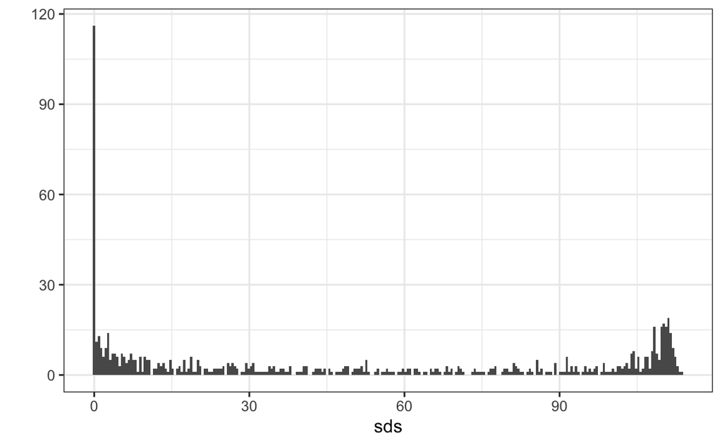

## Preprocessing

- This is expected because there are parts of the image that rarely contain writing (dark pixels).
- The **caret** packages includes a function that recommends features to be removed due to *near zero variance*:

```r
library(caret)
nzv <- nearZeroVar(x)
```

## Preprocessing

- We can see the columns recommended for removal:

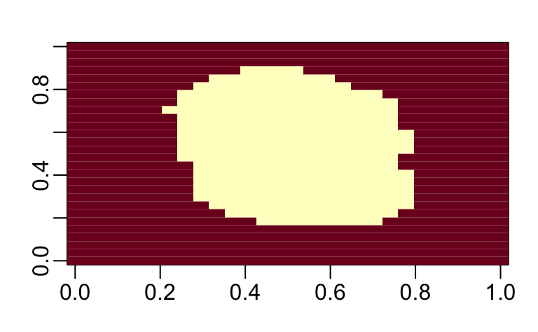

```r
image(matrix(1:784 %in% nzv, 28, 28))
```

## Preprocessing

- So we end up keeping this number of columns:

```r
col_index <- setdiff(1:ncol(x), nzv)
length(col_index)
```

```
#> [1] 252
```

- Now we are ready to fit some models.

## Preprocessing

- Before we start, we need to add column names to the feature matrices as these are required by **caret**:

```r
colnames(x) <- 1:ncol(mnist$train$images)
colnames(x_test) <- colnames(x)
```

## k-nearest neighbor

- Let’s start with kNN.
- The first step is to optimize for \(k\).
- Keep in mind that when we run the algorithm, we will have to compute a distance between each observation in the test set and each observation in the training set.
- There are a lot of computations.
- We will therefore use k-fold cross validation to improve speed.

## k-nearest neighbor

- If we run the following code, the computing time on a standard laptop will be several minutes.

```r
control <- trainControl(method = "cv", number = 10, p = .9)
train_knn <- train(x[ ,col_index], y,
                   method = "knn",
                   tuneGrid = data.frame(k = c(3,5,7)),
                   trControl = control)
train_knn
```

- In general, it is a good idea to try a test run with a subset of the data to get an idea of timing before we start running code that might take hours to complete.

## k-nearest neighbor

- We can do this as follows:

```r
n <- 1000
b <- 2
index <- sample(nrow(x), n)
control <- trainControl(method = "cv", number = b, p = .9)
train_knn <- train(x[index, col_index], y[index],
                   method = "knn",
                   tuneGrid = data.frame(k = c(3,5,7)),
                   trControl = control)
```

- We can then increase `n` and `b` and try to establish a pattern of how they affect computing time.
- to get an idea of how long the fitting process will take for larger values of `n` and `b`.

## k-nearest neighbor

- You want to know if a function is going to take hours, or even days, before you run it.
- Once we optimize our algorithm, we can fit it to the entire dataset:

```r
fit_knn <- knn3(x[, col_index], y,  k = 3)
```

- We now achieve a high accuracy:

```r
y_hat_knn <- predict(fit_knn, x_test[, col_index], type="class")
cm <- confusionMatrix(y_hat_knn, factor(y_test))
cm$overall["Accuracy"]
```

```
#> Accuracy
#>    0.953
```

## k-nearest neighbor

- From the specificity and sensitivity, we also see that 8s are the hardest to detect and the most commonly incorrectly predicted digit is 7.

```r
cm$byClass[,1:2]
```

```
#>          Sensitivity Specificity
#> Class: 0       0.990       0.996
#> Class: 1       1.000       0.993
#> Class: 2       0.965       0.997
#> Class: 3       0.950       0.999
#> Class: 4       0.930       0.997
#> Class: 5       0.921       0.993
#> Class: 6       0.977       0.996
#> Class: 7       0.956       0.989
#> Class: 8       0.887       0.999
#> Class: 9       0.951       0.990
```

## Random forest

- Now let’s see if we can do even better with the random forest algorithm.
- With random forest, computation time is a challenge.
- For each forest, we need to build hundreds of trees.
- We also have several parameters we can tune.

## Random forest

- Because with random forest the fitting is the slowest part of the procedure rather than the predicting (as with kNN), we will use only five-fold cross validation.
- We will also reduce the number of trees that are fit since we are not yet building our final model.
- Finally, to compute on a smaller dataset, we will take a random sample of the observations when constructing each tree.
- We can change this number with the `nSamp` argument.

## Random forest

```r
library(randomForest)
control <- trainControl(method="cv", number = 5)
grid <- data.frame(mtry = c(1, 5, 10, 25, 50, 100))
train_rf <-  train(x[, col_index], y,
                   method = "rf",
                   ntree = 15,
                   trControl = control,
                   tuneGrid = grid,
                   nSamp = 5000)
```

- Now that we have optimized our algorithm, we are ready to fit our final model:

```r
fit_rf <- randomForest(x[, col_index], y,
                       mtry = train_rf$bestTune$mtry,
                       minNode = 10)
```

## Random forest

- To check that we ran enough trees we can use the plot function:

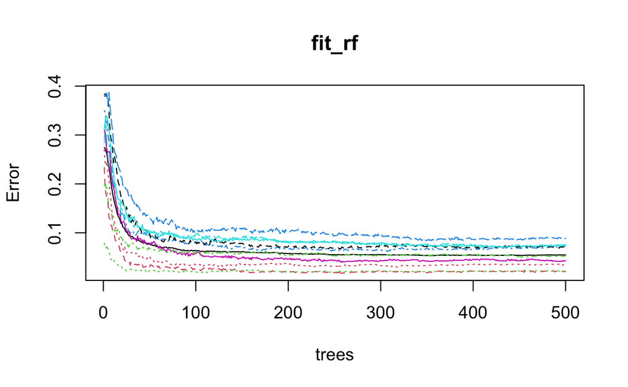

```r
plot(fit_rf)
```

## Random forest

- We see that we achieve high accuracy:

```r
y_hat_rf <- predict(fit_rf, x_test[ ,col_index])
cm <- confusionMatrix(y_hat_rf, y_test)
cm$overall["Accuracy"]
```

```
#> Accuracy
#>    0.956
```

## Random forest

- Here are some examples of the original images and our calls:

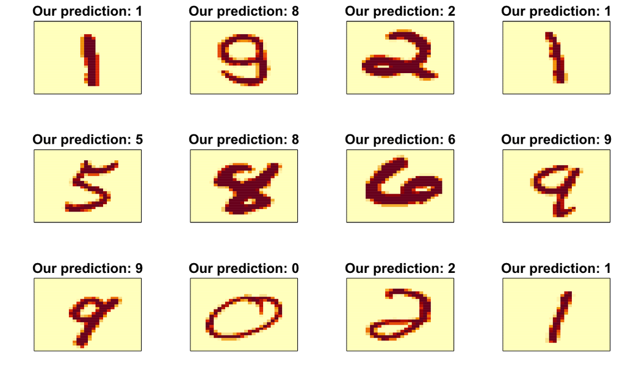

## Random forest

- With some further tuning, we can get even higher accuracy.

## Variable importance

- The following function computes the importance of each feature:

```r
imp <- importance(fit_rf)
```

## Variable importance

- We can see which features are being used most by plotting an image:

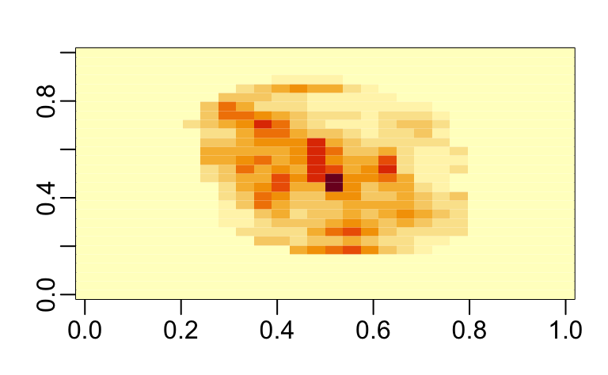

```r
mat <- rep(0, ncol(x))
mat[col_index] <- imp
image(matrix(mat, 28, 28))
```

## Visual assessments

- An important part of data analysis is visualizing results to determine why we are failing.
- How we do this depends on the application.
- Below we show the images of digits for which we made an incorrect prediction.
- We can compare what we get with kNN to random forest.

## Visual assessments

- Here are some errors made by kNN:

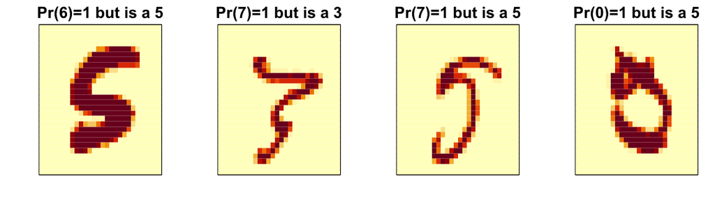

## Visual assessments

- Here are some errors for the random forest:

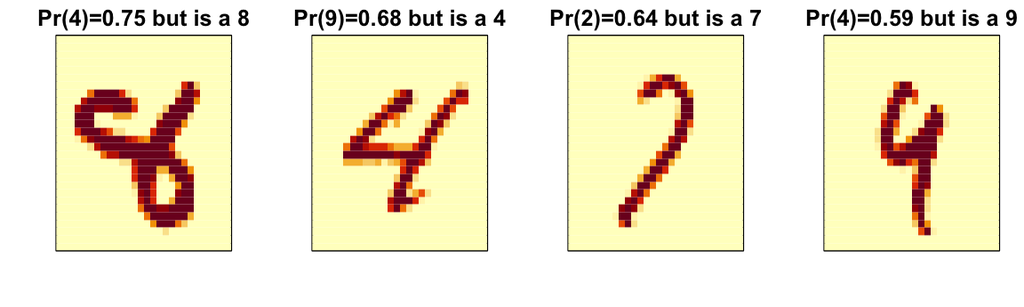

## Visual assessments

- By examining errors like this we often find specific weaknesses to algorithms or parameter choices and can try to correct them.

## Ensembles

- The idea of an ensemble is similar to the idea of combining data from different pollsters to obtain a better estimate of the true support for each candidate.
- In machine learning, one can usually greatly improve the final results by combining the results of different algorithms.
- Here is a simple example where we compute new class probabilities by taking the average of random forest and kNN.

## Ensembles

- We can see that the accuracy improves to 0.96:

```r
p_rf <- predict(fit_rf, x_test[,col_index], type = "prob")
p_rf<- p_rf / rowSums(p_rf)
p_knn  <- predict(fit_knn, x_test[,col_index])
p <- (p_rf + p_knn)/2
y_pred <- factor(apply(p, 1, which.max)-1)
confusionMatrix(y_pred, y_test)$overall["Accuracy"]
```

```
#> Accuracy
#>    0.961
```